# Pandas统计分析基础（2）- DataFrame的合并、分组及其应用

```python
import pandas as pd
import numpy as np
import matplotlib.pyplot as plt
plt.rcParams['font.sans-serif']=['SimHei']
plt.rcParams['axes.unicode_minus']=False  ##针对坐标轴中负号显示不出来的问题
```

```python
pop=pd.read_excel('GDPandPopulation.xlsx',sheet_name='Population',index_col=0)
gdp=pd.read_excel('GDPandPopulation.xlsx',sheet_name='GDP',index_col=0)
```

```python
pop.head() #DataFrame.head()  可以读取Dataframe的前n行，默认n=5
```

| 省份 | 2018年 |
| --- | --- |
| 北京市 | 2154 |
| 天津市 | 1560 |
| 河北省 | 7556 |
| 山西省 | 3718 |
| 内蒙古自治区 | 2534 |

```python
len(gdp)   #len()可以返回DtaFrame的行数
```

```
31
```

## 1.DataFrame的合并

**DataFrame可以保存任意维度的数据。 我们尝试将gdp和pop两个dataframe合并成一个。**

### 1.1 concat方法

#### 1.1.1 concat横向合并

```python
df=pd.concat([gdp,pop],axis=1) ##axis=0是纵向，=1是横向
```

```python
df
```

| 省份 | 2018年 | 2018年 |
| --- | --- | --- |
| 北京市 | 30319.98 | 2154 |
| 天津市 | 18809.64 | 1560 |
| 河北省 | 36010.27 | 7556 |
| 山西省 | 16818.11 | 3718 |
| 内蒙古自治区 | 17289.22 | 2534 |
| 辽宁省 | 25315.35 | 4359 |
| 吉林省 | 15074.62 | 2704 |
| 黑龙江省 | 16361.62 | 3773 |
| 上海市 | 32679.87 | 2424 |
| 江苏省 | 92595.40 | 8051 |
| 浙江省 | 56197.15 | 5737 |
| 安徽省 | 30006.82 | 6324 |
| 福建省 | 35804.04 | 3941 |
| 江西省 | 21984.78 | 4648 |
| 山东省 | 76469.67 | 10047 |
| 河南省 | 48055.86 | 9605 |
| 湖北省 | 39366.55 | 5917 |
| 湖南省 | 36425.78 | 6899 |
| 广东省 | 97277.77 | 11346 |
| 广西壮族自治区 | 20352.51 | 4926 |
| 海南省 | 4832.05 | 934 |
| 重庆市 | 20363.19 | 3102 |
| 四川省 | 40678.13 | 8341 |
| 贵州省 | 14806.45 | 3600 |
| 云南省 | 17881.12 | 4830 |
| 西藏自治区 | 1477.63 | 344 |
| 陕西省 | 24438.32 | 3864 |
| 甘肃省 | 8246.07 | 2637 |
| 青海省 | 2865.23 | 603 |
| 宁夏回族自治区 | 3705.18 | 688 |
| 新疆维吾尔自治区 | 12199.08 | 2487 |

因此需要修改列名，使用DataFrame.rename()方法

```python
gdp.rename(columns={'2018年': 'GDP'},inplace=True)
#字典中，key为旧名字，value为新名字，key值不存在就不不改名，不会报错
gdp
```

| 省份 | GDP |
| --- | --- |
| 北京市 | 30319.98 |
| 天津市 | 18809.64 |
| 河北省 | 36010.27 |
| 山西省 | 16818.11 |
| 内蒙古自治区 | 17289.22 |
| 辽宁省 | 25315.35 |
| 吉林省 | 15074.62 |
| 黑龙江省 | 16361.62 |
| 上海市 | 32679.87 |
| 江苏省 | 92595.40 |
| 浙江省 | 56197.15 |
| 安徽省 | 30006.82 |
| 福建省 | 35804.04 |
| 江西省 | 21984.78 |
| 山东省 | 76469.67 |
| 河南省 | 48055.86 |
| 湖北省 | 39366.55 |
| 湖南省 | 36425.78 |
| 广东省 | 97277.77 |
| 广西壮族自治区 | 20352.51 |
| 海南省 | 4832.05 |
| 重庆市 | 20363.19 |
| 四川省 | 40678.13 |
| 贵州省 | 14806.45 |
| 云南省 | 17881.12 |
| 西藏自治区 | 1477.63 |
| 陕西省 | 24438.32 |
| 甘肃省 | 8246.07 |
| 青海省 | 2865.23 |
| 宁夏回族自治区 | 3705.18 |
| 新疆维吾尔自治区 | 12199.08 |

先建好改名字典再统一改

```python
pop_newname={'2018年': 'POP'}
pop.rename(columns=pop_newname,inplace=True)
pop
```

| 省份 | POP |
| --- | --- |
| 北京市 | 2154 |
| 天津市 | 1560 |
| 河北省 | 7556 |
| 山西省 | 3718 |
| 内蒙古自治区 | 2534 |
| 辽宁省 | 4359 |
| 吉林省 | 2704 |
| 黑龙江省 | 3773 |
| 上海市 | 2424 |
| 江苏省 | 8051 |
| 浙江省 | 5737 |
| 安徽省 | 6324 |
| 福建省 | 3941 |
| 江西省 | 4648 |
| 山东省 | 10047 |
| 河南省 | 9605 |
| 湖北省 | 5917 |
| 湖南省 | 6899 |
| 广东省 | 11346 |
| 广西壮族自治区 | 4926 |
| 海南省 | 934 |
| 重庆市 | 3102 |
| 四川省 | 8341 |
| 贵州省 | 3600 |
| 云南省 | 4830 |
| 西藏自治区 | 344 |
| 陕西省 | 3864 |
| 甘肃省 | 2637 |
| 青海省 | 603 |
| 宁夏回族自治区 | 688 |
| 新疆维吾尔自治区 | 2487 |

```python
df_combine=pd.concat([gdp,pop],axis=1)  #axis=1即行索引
df_combine
```

| 省份 | GDP | POP |
| --- | --- | --- |
| 北京市 | 30319.98 | 2154 |
| 天津市 | 18809.64 | 1560 |
| 河北省 | 36010.27 | 7556 |
| 山西省 | 16818.11 | 3718 |
| 内蒙古自治区 | 17289.22 | 2534 |
| 辽宁省 | 25315.35 | 4359 |
| 吉林省 | 15074.62 | 2704 |
| 黑龙江省 | 16361.62 | 3773 |
| 上海市 | 32679.87 | 2424 |
| 江苏省 | 92595.40 | 8051 |
| 浙江省 | 56197.15 | 5737 |
| 安徽省 | 30006.82 | 6324 |
| 福建省 | 35804.04 | 3941 |
| 江西省 | 21984.78 | 4648 |
| 山东省 | 76469.67 | 10047 |
| 河南省 | 48055.86 | 9605 |
| 湖北省 | 39366.55 | 5917 |
| 湖南省 | 36425.78 | 6899 |
| 广东省 | 97277.77 | 11346 |
| 广西壮族自治区 | 20352.51 | 4926 |
| 海南省 | 4832.05 | 934 |
| 重庆市 | 20363.19 | 3102 |
| 四川省 | 40678.13 | 8341 |
| 贵州省 | 14806.45 | 3600 |
| 云南省 | 17881.12 | 4830 |
| 西藏自治区 | 1477.63 | 344 |
| 陕西省 | 24438.32 | 3864 |
| 甘肃省 | 8246.07 | 2637 |
| 青海省 | 2865.23 | 603 |
| 宁夏回族自治区 | 3705.18 | 688 |
| 新疆维吾尔自治区 | 12199.08 | 2487 |

#### 1.1.2 concat纵向合并

```python
df1=df_combine[:][0:5]
df2=df_combine[:][5:]
```

```python
df1
```

| 省份 | GDP | POP |
| --- | --- | --- |
| 北京市 | 30319.98 | 2154 |
| 天津市 | 18809.64 | 1560 |
| 河北省 | 36010.27 | 7556 |
| 山西省 | 16818.11 | 3718 |
| 内蒙古自治区 | 17289.22 | 2534 |

```python
df2
```

| 省份 | GDP | POP |
| --- | --- | --- |
| 辽宁省 | 25315.35 | 4359 |
| 吉林省 | 15074.62 | 2704 |
| 黑龙江省 | 16361.62 | 3773 |
| 上海市 | 32679.87 | 2424 |
| 江苏省 | 92595.40 | 8051 |
| 浙江省 | 56197.15 | 5737 |
| 安徽省 | 30006.82 | 6324 |
| 福建省 | 35804.04 | 3941 |
| 江西省 | 21984.78 | 4648 |
| 山东省 | 76469.67 | 10047 |
| 河南省 | 48055.86 | 9605 |
| 湖北省 | 39366.55 | 5917 |
| 湖南省 | 36425.78 | 6899 |
| 广东省 | 97277.77 | 11346 |
| 广西壮族自治区 | 20352.51 | 4926 |
| 海南省 | 4832.05 | 934 |
| 重庆市 | 20363.19 | 3102 |
| 四川省 | 40678.13 | 8341 |
| 贵州省 | 14806.45 | 3600 |
| 云南省 | 17881.12 | 4830 |
| 西藏自治区 | 1477.63 | 344 |
| 陕西省 | 24438.32 | 3864 |
| 甘肃省 | 8246.07 | 2637 |
| 青海省 | 2865.23 | 603 |
| 宁夏回族自治区 | 3705.18 | 688 |
| 新疆维吾尔自治区 | 12199.08 | 2487 |

```python
df3=pd.concat([df2,df1],axis=0) #axis=0表示纵向合并
df3
```

| 省份 | GDP | POP |
| --- | --- | --- |
| 辽宁省 | 25315.35 | 4359 |
| 吉林省 | 15074.62 | 2704 |
| 黑龙江省 | 16361.62 | 3773 |
| 上海市 | 32679.87 | 2424 |
| 江苏省 | 92595.40 | 8051 |
| 浙江省 | 56197.15 | 5737 |
| 安徽省 | 30006.82 | 6324 |
| 福建省 | 35804.04 | 3941 |
| 江西省 | 21984.78 | 4648 |
| 山东省 | 76469.67 | 10047 |
| 河南省 | 48055.86 | 9605 |
| 湖北省 | 39366.55 | 5917 |
| 湖南省 | 36425.78 | 6899 |
| 广东省 | 97277.77 | 11346 |
| 广西壮族自治区 | 20352.51 | 4926 |
| 海南省 | 4832.05 | 934 |
| 重庆市 | 20363.19 | 3102 |
| 四川省 | 40678.13 | 8341 |
| 贵州省 | 14806.45 | 3600 |
| 云南省 | 17881.12 | 4830 |
| 西藏自治区 | 1477.63 | 344 |
| 陕西省 | 24438.32 | 3864 |
| 甘肃省 | 8246.07 | 2637 |
| 青海省 | 2865.23 | 603 |
| 宁夏回族自治区 | 3705.18 | 688 |
| 新疆维吾尔自治区 | 12199.08 | 2487 |
| 北京市 | 30319.98 | 2154 |
| 天津市 | 18809.64 | 1560 |
| 河北省 | 36010.27 | 7556 |
| 山西省 | 16818.11 | 3718 |
| 内蒙古自治区 | 17289.22 | 2534 |

```python
df1
```

| 省份 | GDP | POP |
| --- | --- | --- |
| 北京市 | 30319.98 | 2154 |
| 天津市 | 18809.64 | 1560 |
| 河北省 | 36010.27 | 7556 |
| 山西省 | 16818.11 | 3718 |
| 内蒙古自治区 | 17289.22 | 2534 |

```python
df2
```

| 省份 | GDP | POP |
| --- | --- | --- |
| 辽宁省 | 25315.35 | 4359 |
| 吉林省 | 15074.62 | 2704 |
| 黑龙江省 | 16361.62 | 3773 |
| 上海市 | 32679.87 | 2424 |
| 江苏省 | 92595.40 | 8051 |
| 浙江省 | 56197.15 | 5737 |
| 安徽省 | 30006.82 | 6324 |
| 福建省 | 35804.04 | 3941 |
| 江西省 | 21984.78 | 4648 |
| 山东省 | 76469.67 | 10047 |
| 河南省 | 48055.86 | 9605 |
| 湖北省 | 39366.55 | 5917 |
| 湖南省 | 36425.78 | 6899 |
| 广东省 | 97277.77 | 11346 |
| 广西壮族自治区 | 20352.51 | 4926 |
| 海南省 | 4832.05 | 934 |
| 重庆市 | 20363.19 | 3102 |
| 四川省 | 40678.13 | 8341 |
| 贵州省 | 14806.45 | 3600 |
| 云南省 | 17881.12 | 4830 |
| 西藏自治区 | 1477.63 | 344 |
| 陕西省 | 24438.32 | 3864 |
| 甘肃省 | 8246.07 | 2637 |
| 青海省 | 2865.23 | 603 |
| 宁夏回族自治区 | 3705.18 | 688 |
| 新疆维吾尔自治区 | 12199.08 | 2487 |

#### 1.1.3 append方法的纵向合并

```python
a=[0]
```

```python
a.append(8)
```

```python
a
```

```
[0, 8]
```

```python
df4=df1.append(df2)
df4
```

| 省份 | GDP | POP |
| --- | --- | --- |
| 北京市 | 30319.98 | 2154 |
| 天津市 | 18809.64 | 1560 |
| 河北省 | 36010.27 | 7556 |
| 山西省 | 16818.11 | 3718 |
| 内蒙古自治区 | 17289.22 | 2534 |
| 辽宁省 | 25315.35 | 4359 |
| 吉林省 | 15074.62 | 2704 |
| 黑龙江省 | 16361.62 | 3773 |
| 上海市 | 32679.87 | 2424 |
| 江苏省 | 92595.40 | 8051 |
| 浙江省 | 56197.15 | 5737 |
| 安徽省 | 30006.82 | 6324 |
| 福建省 | 35804.04 | 3941 |
| 江西省 | 21984.78 | 4648 |
| 山东省 | 76469.67 | 10047 |
| 河南省 | 48055.86 | 9605 |
| 湖北省 | 39366.55 | 5917 |
| 湖南省 | 36425.78 | 6899 |
| 广东省 | 97277.77 | 11346 |
| 广西壮族自治区 | 20352.51 | 4926 |
| 海南省 | 4832.05 | 934 |
| 重庆市 | 20363.19 | 3102 |
| 四川省 | 40678.13 | 8341 |
| 贵州省 | 14806.45 | 3600 |
| 云南省 | 17881.12 | 4830 |
| 西藏自治区 | 1477.63 | 344 |
| 陕西省 | 24438.32 | 3864 |
| 甘肃省 | 8246.07 | 2637 |
| 青海省 | 2865.23 | 603 |
| 宁夏回族自治区 | 3705.18 | 688 |
| 新疆维吾尔自治区 | 12199.08 | 2487 |

```python
df1
```

| 省份 | GDP | POP |
| --- | --- | --- |
| 北京市 | 30319.98 | 2154 |
| 天津市 | 18809.64 | 1560 |
| 河北省 | 36010.27 | 7556 |
| 山西省 | 16818.11 | 3718 |
| 内蒙古自治区 | 17289.22 | 2534 |

**可见，上述合并方式均不会改变原dataframe**

#### 1.1.4 使用concat合并时，可以添加keys参数来区分来自哪个dataframe

```python
pop=pd.read_excel('GDPandPopulation.xlsx',sheet_name='Population',index_col=0)
gdp=pd.read_excel('GDPandPopulation.xlsx',sheet_name='GDP',index_col=0)
pop.head()
```

| 省份 | 2018年 |
| --- | --- |
| 北京市 | 2154 |
| 天津市 | 1560 |
| 河北省 | 7556 |
| 山西省 | 3718 |
| 内蒙古自治区 | 2534 |

```python
pop.index
```

```
Index(['北京市', '天津市', '河北省', '山西省', '内蒙古自治区', '辽宁省', '吉林省', '黑龙江省', '上海市',
       '江苏省', '浙江省', '安徽省', '福建省', '江西省', '山东省', '河南省', '湖北省', '湖南省', '广东省',
       '广西壮族自治区', '海南省', '重庆市', '四川省', '贵州省', '云南省', '西藏自治区', '陕西省', '甘肃省',
       '青海省', '宁夏回族自治区', '新疆维吾尔自治区'],
      dtype='object', name='省份')
```

```python
df5=pd.concat([pop,gdp],axis=0,keys=['pop','gdp'])  #不用改名字即可合并
df5
```

|  | 省份 | 2018年 |
| --- | --- | --- |
| pop | 北京市 | 2154.00 |
|  | 天津市 | 1560.00 |
|  | 河北省 | 7556.00 |
|  | 山西省 | 3718.00 |
|  | 内蒙古自治区 | 2534.00 |
| ... | ... | ... |
| gdp | 陕西省 | 24438.32 |
|  | 甘肃省 | 8246.07 |
|  | 青海省 | 2865.23 |
|  | 宁夏回族自治区 | 3705.18 |
|  | 新疆维吾尔自治区 | 12199.08 |

62 rows × 1 columns

```python
df5.index #index变成了2个元素的tuple组成的multiindex
```

```
MultiIndex([('pop',      '北京市'),
            ('pop',      '天津市'),
            ('pop',      '河北省'),
            ('pop',      '山西省'),
            ('pop',   '内蒙古自治区'),
            ('pop',      '辽宁省'),
            ('pop',      '吉林省'),
            ('pop',     '黑龙江省'),
            ('pop',      '上海市'),
            ('pop',      '江苏省'),
            ('pop',      '浙江省'),
            ('pop',      '安徽省'),
            ('pop',      '福建省'),
            ('pop',      '江西省'),
            ('pop',      '山东省'),
            ('pop',      '河南省'),
            ('pop',      '湖北省'),
            ('pop',      '湖南省'),
            ('pop',      '广东省'),
            ('pop',  '广西壮族自治区'),
            ('pop',      '海南省'),
            ('pop',      '重庆市'),
            ('pop',      '四川省'),
            ('pop',      '贵州省'),
            ('pop',      '云南省'),
            ('pop',    '西藏自治区'),
            ('pop',      '陕西省'),
            ('pop',      '甘肃省'),
            ('pop',      '青海省'),
            ('pop',  '宁夏回族自治区'),
            ('pop', '新疆维吾尔自治区'),
            ('gdp',      '北京市'),
            ('gdp',      '天津市'),
            ('gdp',      '河北省'),
            ('gdp',      '山西省'),
            ('gdp',   '内蒙古自治区'),
            ('gdp',      '辽宁省'),
            ('gdp',      '吉林省'),
            ('gdp',     '黑龙江省'),
            ('gdp',      '上海市'),
```

[output cut: 8 more lines]

```
            ('gdp',      '湖南省'),
            ('gdp',      '广东省'),
            ('gdp',  '广西壮族自治区'),
            ('gdp',      '海南省'),
            ('gdp',      '重庆市'),
            ('gdp',      '四川省'),
            ('gdp',      '贵州省'),
            ('gdp',      '云南省'),
            ('gdp',    '西藏自治区'),
            ('gdp',      '陕西省'),
            ('gdp',      '甘肃省'),
            ('gdp',      '青海省'),
            ('gdp',  '宁夏回族自治区'),
            ('gdp', '新疆维吾尔自治区')],
           names=[None, '省份'])
```

```python
df5.loc['pop']#可以通过multiindex的第一个index调用
```

| 省份 | 2018年 |
| --- | --- |
| 北京市 | 2154.0 |
| 天津市 | 1560.0 |
| 河北省 | 7556.0 |
| 山西省 | 3718.0 |
| 内蒙古自治区 | 2534.0 |
| 辽宁省 | 4359.0 |
| 吉林省 | 2704.0 |
| 黑龙江省 | 3773.0 |
| 上海市 | 2424.0 |
| 江苏省 | 8051.0 |
| 浙江省 | 5737.0 |
| 安徽省 | 6324.0 |
| 福建省 | 3941.0 |
| 江西省 | 4648.0 |
| 山东省 | 10047.0 |
| 河南省 | 9605.0 |
| 湖北省 | 5917.0 |
| 湖南省 | 6899.0 |
| 广东省 | 11346.0 |
| 广西壮族自治区 | 4926.0 |
| 海南省 | 934.0 |
| 重庆市 | 3102.0 |
| 四川省 | 8341.0 |
| 贵州省 | 3600.0 |
| 云南省 | 4830.0 |
| 西藏自治区 | 344.0 |
| 陕西省 | 3864.0 |
| 甘肃省 | 2637.0 |
| 青海省 | 603.0 |
| 宁夏回族自治区 | 688.0 |
| 新疆维吾尔自治区 | 2487.0 |

```python
df5.loc['pop','北京市']#也可以把index写全
```

```
2018年    2154.0
Name: (pop, 北京市), dtype: float64
```

```python
df5.loc['pop','北京市']['2018年']
```

```
2154.0
```

### 1.2 使用join函数合并表，常用于行索引相同的两个dataframe

```python
gdp
```

| 省份 | 2018年 |
| --- | --- |
| 北京市 | 30319.98 |
| 天津市 | 18809.64 |
| 河北省 | 36010.27 |
| 山西省 | 16818.11 |
| 内蒙古自治区 | 17289.22 |
| 辽宁省 | 25315.35 |
| 吉林省 | 15074.62 |
| 黑龙江省 | 16361.62 |
| 上海市 | 32679.87 |
| 江苏省 | 92595.40 |
| 浙江省 | 56197.15 |
| 安徽省 | 30006.82 |
| 福建省 | 35804.04 |
| 江西省 | 21984.78 |
| 山东省 | 76469.67 |
| 河南省 | 48055.86 |
| 湖北省 | 39366.55 |
| 湖南省 | 36425.78 |
| 广东省 | 97277.77 |
| 广西壮族自治区 | 20352.51 |
| 海南省 | 4832.05 |
| 重庆市 | 20363.19 |
| 四川省 | 40678.13 |
| 贵州省 | 14806.45 |
| 云南省 | 17881.12 |
| 西藏自治区 | 1477.63 |
| 陕西省 | 24438.32 |
| 甘肃省 | 8246.07 |
| 青海省 | 2865.23 |
| 宁夏回族自治区 | 3705.18 |
| 新疆维吾尔自治区 | 12199.08 |

```python
df6=pop.join(gdp,lsuffix='_pop', rsuffix='_gdp') #两个dataframe列名相同，需要加lsuffix或rsuffix在左边/右边的列名上加后缀来区分
df6
```

| 省份 | 2018年_pop | 2018年_gdp |
| --- | --- | --- |
| 北京市 | 2154 | 30319.98 |
| 天津市 | 1560 | 18809.64 |
| 河北省 | 7556 | 36010.27 |
| 山西省 | 3718 | 16818.11 |
| 内蒙古自治区 | 2534 | 17289.22 |
| 辽宁省 | 4359 | 25315.35 |
| 吉林省 | 2704 | 15074.62 |
| 黑龙江省 | 3773 | 16361.62 |
| 上海市 | 2424 | 32679.87 |
| 江苏省 | 8051 | 92595.40 |
| 浙江省 | 5737 | 56197.15 |
| 安徽省 | 6324 | 30006.82 |
| 福建省 | 3941 | 35804.04 |
| 江西省 | 4648 | 21984.78 |
| 山东省 | 10047 | 76469.67 |
| 河南省 | 9605 | 48055.86 |
| 湖北省 | 5917 | 39366.55 |
| 湖南省 | 6899 | 36425.78 |
| 广东省 | 11346 | 97277.77 |
| 广西壮族自治区 | 4926 | 20352.51 |
| 海南省 | 934 | 4832.05 |
| 重庆市 | 3102 | 20363.19 |
| 四川省 | 8341 | 40678.13 |
| 贵州省 | 3600 | 14806.45 |
| 云南省 | 4830 | 17881.12 |
| 西藏自治区 | 344 | 1477.63 |
| 陕西省 | 3864 | 24438.32 |
| 甘肃省 | 2637 | 8246.07 |
| 青海省 | 603 | 2865.23 |
| 宁夏回族自治区 | 688 | 3705.18 |
| 新疆维吾尔自治区 | 2487 | 12199.08 |

```python
region=pd.read_excel('GDPandPopulation.xlsx',sheet_name='region',index_col=0)
region
```

| 省份 | 区域 |
| --- | --- |
| 北京市 | 华北 |
| 天津市 | 华北 |
| 河北省 | 华北 |
| 山西省 | 华北 |
| 内蒙古自治区 | 华北 |
| 辽宁省 | 东北 |
| 吉林省 | 东北 |
| 黑龙江省 | 东北 |
| 上海市 | 华东 |
| 江苏省 | 华东 |
| 浙江省 | 华东 |
| 安徽省 | 华东 |
| 福建省 | 华东 |
| 江西省 | 华东 |
| 山东省 | 华东 |
| 河南省 | 中南 |
| 湖北省 | 中南 |
| 湖南省 | 中南 |
| 广东省 | 中南 |
| 广西壮族自治区 | 中南 |
| 海南省 | 中南 |
| 重庆市 | 西南 |
| 四川省 | 西南 |
| 贵州省 | 西南 |
| 云南省 | 西南 |
| 西藏自治区 | 西南 |
| 陕西省 | 西北 |
| 甘肃省 | 西北 |
| 青海省 | 西北 |
| 宁夏回族自治区 | 西北 |
| 新疆维吾尔自治区 | 西北 |

```python
df7=df6.join(region) #没有重名列可以直接使用
df7
```

| 省份 | 2018年_pop | 2018年_gdp | 区域 |
| --- | --- | --- | --- |
| 北京市 | 2154 | 30319.98 | 华北 |
| 天津市 | 1560 | 18809.64 | 华北 |
| 河北省 | 7556 | 36010.27 | 华北 |
| 山西省 | 3718 | 16818.11 | 华北 |
| 内蒙古自治区 | 2534 | 17289.22 | 华北 |
| 辽宁省 | 4359 | 25315.35 | 东北 |
| 吉林省 | 2704 | 15074.62 | 东北 |
| 黑龙江省 | 3773 | 16361.62 | 东北 |
| 上海市 | 2424 | 32679.87 | 华东 |
| 江苏省 | 8051 | 92595.40 | 华东 |
| 浙江省 | 5737 | 56197.15 | 华东 |
| 安徽省 | 6324 | 30006.82 | 华东 |
| 福建省 | 3941 | 35804.04 | 华东 |
| 江西省 | 4648 | 21984.78 | 华东 |
| 山东省 | 10047 | 76469.67 | 华东 |
| 河南省 | 9605 | 48055.86 | 中南 |
| 湖北省 | 5917 | 39366.55 | 中南 |
| 湖南省 | 6899 | 36425.78 | 中南 |
| 广东省 | 11346 | 97277.77 | 中南 |
| 广西壮族自治区 | 4926 | 20352.51 | 中南 |
| 海南省 | 934 | 4832.05 | 中南 |
| 重庆市 | 3102 | 20363.19 | 西南 |
| 四川省 | 8341 | 40678.13 | 西南 |
| 贵州省 | 3600 | 14806.45 | 西南 |
| 云南省 | 4830 | 17881.12 | 西南 |
| 西藏自治区 | 344 | 1477.63 | 西南 |
| 陕西省 | 3864 | 24438.32 | 西北 |
| 甘肃省 | 2637 | 8246.07 | 西北 |
| 青海省 | 603 | 2865.23 | 西北 |
| 宁夏回族自治区 | 688 | 3705.18 | 西北 |
| 新疆维吾尔自治区 | 2487 | 12199.08 | 西北 |

### 1.3 使用merge方法进行合并

```python
df8=pd.merge(pop,gdp,left_index=True,right_index=True)  #以两个dataframe的index来合并，与join相同
df8
```

| 省份 | 2018年_x | 2018年_y |
| --- | --- | --- |
| 北京市 | 2154 | 30319.98 |
| 天津市 | 1560 | 18809.64 |
| 河北省 | 7556 | 36010.27 |
| 山西省 | 3718 | 16818.11 |
| 内蒙古自治区 | 2534 | 17289.22 |
| 辽宁省 | 4359 | 25315.35 |
| 吉林省 | 2704 | 15074.62 |
| 黑龙江省 | 3773 | 16361.62 |
| 上海市 | 2424 | 32679.87 |
| 江苏省 | 8051 | 92595.40 |
| 浙江省 | 5737 | 56197.15 |
| 安徽省 | 6324 | 30006.82 |
| 福建省 | 3941 | 35804.04 |
| 江西省 | 4648 | 21984.78 |
| 山东省 | 10047 | 76469.67 |
| 河南省 | 9605 | 48055.86 |
| 湖北省 | 5917 | 39366.55 |
| 湖南省 | 6899 | 36425.78 |
| 广东省 | 11346 | 97277.77 |
| 广西壮族自治区 | 4926 | 20352.51 |
| 海南省 | 934 | 4832.05 |
| 重庆市 | 3102 | 20363.19 |
| 四川省 | 8341 | 40678.13 |
| 贵州省 | 3600 | 14806.45 |
| 云南省 | 4830 | 17881.12 |
| 西藏自治区 | 344 | 1477.63 |
| 陕西省 | 3864 | 24438.32 |
| 甘肃省 | 2637 | 8246.07 |
| 青海省 | 603 | 2865.23 |
| 宁夏回族自治区 | 688 | 3705.18 |
| 新疆维吾尔自治区 | 2487 | 12199.08 |

```python
pop=pd.read_excel('GDPandPopulation.xlsx',sheet_name='Population')
gdp=pd.read_excel('GDPandPopulation.xlsx',sheet_name='GDP')
#重新读入pop和gdp，并把省份名称纳入dataframe中
pop
```

|  | 省份 | 2018年 |
| --- | --- | --- |
| 0 | 北京市 | 2154 |
| 1 | 天津市 | 1560 |
| 2 | 河北省 | 7556 |
| 3 | 山西省 | 3718 |
| 4 | 内蒙古自治区 | 2534 |
| 5 | 辽宁省 | 4359 |
| 6 | 吉林省 | 2704 |
| 7 | 黑龙江省 | 3773 |
| 8 | 上海市 | 2424 |
| 9 | 江苏省 | 8051 |
| 10 | 浙江省 | 5737 |
| 11 | 安徽省 | 6324 |
| 12 | 福建省 | 3941 |
| 13 | 江西省 | 4648 |
| 14 | 山东省 | 10047 |
| 15 | 河南省 | 9605 |
| 16 | 湖北省 | 5917 |
| 17 | 湖南省 | 6899 |
| 18 | 广东省 | 11346 |
| 19 | 广西壮族自治区 | 4926 |
| 20 | 海南省 | 934 |
| 21 | 重庆市 | 3102 |
| 22 | 四川省 | 8341 |
| 23 | 贵州省 | 3600 |
| 24 | 云南省 | 4830 |
| 25 | 西藏自治区 | 344 |
| 26 | 陕西省 | 3864 |
| 27 | 甘肃省 | 2637 |
| 28 | 青海省 | 603 |
| 29 | 宁夏回族自治区 | 688 |
| 30 | 新疆维吾尔自治区 | 2487 |

```python
pop['数据']='pop'
gdp['数据']='gdp'
gdp
```

|  | 省份 | 2018年 | 数据 |
| --- | --- | --- | --- |
| 0 | 北京市 | 30319.98 | gdp |
| 1 | 天津市 | 18809.64 | gdp |
| 2 | 河北省 | 36010.27 | gdp |
| 3 | 山西省 | 16818.11 | gdp |
| 4 | 内蒙古自治区 | 17289.22 | gdp |
| 5 | 辽宁省 | 25315.35 | gdp |
| 6 | 吉林省 | 15074.62 | gdp |
| 7 | 黑龙江省 | 16361.62 | gdp |
| 8 | 上海市 | 32679.87 | gdp |
| 9 | 江苏省 | 92595.40 | gdp |
| 10 | 浙江省 | 56197.15 | gdp |
| 11 | 安徽省 | 30006.82 | gdp |
| 12 | 福建省 | 35804.04 | gdp |
| 13 | 江西省 | 21984.78 | gdp |
| 14 | 山东省 | 76469.67 | gdp |
| 15 | 河南省 | 48055.86 | gdp |
| 16 | 湖北省 | 39366.55 | gdp |
| 17 | 湖南省 | 36425.78 | gdp |
| 18 | 广东省 | 97277.77 | gdp |
| 19 | 广西壮族自治区 | 20352.51 | gdp |
| 20 | 海南省 | 4832.05 | gdp |
| 21 | 重庆市 | 20363.19 | gdp |
| 22 | 四川省 | 40678.13 | gdp |
| 23 | 贵州省 | 14806.45 | gdp |
| 24 | 云南省 | 17881.12 | gdp |
| 25 | 西藏自治区 | 1477.63 | gdp |
| 26 | 陕西省 | 24438.32 | gdp |
| 27 | 甘肃省 | 8246.07 | gdp |
| 28 | 青海省 | 2865.23 | gdp |
| 29 | 宁夏回族自治区 | 3705.18 | gdp |
| 30 | 新疆维吾尔自治区 | 12199.08 | gdp |

```python
df9=pd.merge(pop,gdp,how='outer',on=['省份','2018年'])
#how='outer'表示求两个dataframe的并集，on=[列名]表示合并依照的列，即保持列名不变的列
df9
```

|  | 省份 | 2018年 | 数据_x | 数据_y |
| --- | --- | --- | --- | --- |
| 0 | 北京市 | 2154.00 | pop | NaN |
| 1 | 天津市 | 1560.00 | pop | NaN |
| 2 | 河北省 | 7556.00 | pop | NaN |
| 3 | 山西省 | 3718.00 | pop | NaN |
| 4 | 内蒙古自治区 | 2534.00 | pop | NaN |
| ... | ... | ... | ... | ... |
| 57 | 陕西省 | 24438.32 | NaN | gdp |
| 58 | 甘肃省 | 8246.07 | NaN | gdp |
| 59 | 青海省 | 2865.23 | NaN | gdp |
| 60 | 宁夏回族自治区 | 3705.18 | NaN | gdp |
| 61 | 新疆维吾尔自治区 | 12199.08 | NaN | gdp |

62 rows × 4 columns

## 2. 基于groupby的数据分组

```python
df7
```

| 省份 | 2018年_pop | 2018年_gdp | 区域 |
| --- | --- | --- | --- |
| 北京市 | 2154 | 30319.98 | 华北 |
| 天津市 | 1560 | 18809.64 | 华北 |
| 河北省 | 7556 | 36010.27 | 华北 |
| 山西省 | 3718 | 16818.11 | 华北 |
| 内蒙古自治区 | 2534 | 17289.22 | 华北 |
| 辽宁省 | 4359 | 25315.35 | 东北 |
| 吉林省 | 2704 | 15074.62 | 东北 |
| 黑龙江省 | 3773 | 16361.62 | 东北 |
| 上海市 | 2424 | 32679.87 | 华东 |
| 江苏省 | 8051 | 92595.40 | 华东 |
| 浙江省 | 5737 | 56197.15 | 华东 |
| 安徽省 | 6324 | 30006.82 | 华东 |
| 福建省 | 3941 | 35804.04 | 华东 |
| 江西省 | 4648 | 21984.78 | 华东 |
| 山东省 | 10047 | 76469.67 | 华东 |
| 河南省 | 9605 | 48055.86 | 中南 |
| 湖北省 | 5917 | 39366.55 | 中南 |
| 湖南省 | 6899 | 36425.78 | 中南 |
| 广东省 | 11346 | 97277.77 | 中南 |
| 广西壮族自治区 | 4926 | 20352.51 | 中南 |
| 海南省 | 934 | 4832.05 | 中南 |
| 重庆市 | 3102 | 20363.19 | 西南 |
| 四川省 | 8341 | 40678.13 | 西南 |
| 贵州省 | 3600 | 14806.45 | 西南 |
| 云南省 | 4830 | 17881.12 | 西南 |
| 西藏自治区 | 344 | 1477.63 | 西南 |
| 陕西省 | 3864 | 24438.32 | 西北 |
| 甘肃省 | 2637 | 8246.07 | 西北 |
| 青海省 | 603 | 2865.23 | 西北 |
| 宁夏回族自治区 | 688 | 3705.18 | 西北 |
| 新疆维吾尔自治区 | 2487 | 12199.08 | 西北 |

```python
group_region=df7.groupby(by='区域')  #以'区域'这一列进行分类，值相同的行被并为一类
```

```python
group_region
```

```
<pandas.core.groupby.generic.DataFrameGroupBy object at 0x00000290B94914C0>
```

### 2.1groupby是什么

```python
len(group_region)
```

```
6
```

```python
group_region[0]
```

[output not shown]

```python
for i in group_region:
    print(i)
```

```
('东北',       2018年_pop  2018年_gdp  区域
省份
辽宁省        4359   25315.35  东北
吉林省        2704   15074.62  东北
黑龙江省       3773   16361.62  东北)
('中南',          2018年_pop  2018年_gdp  区域
省份
河南省           9605   48055.86  中南
湖北省           5917   39366.55  中南
湖南省           6899   36425.78  中南
广东省          11346   97277.77  中南
广西壮族自治区       4926   20352.51  中南
海南省            934    4832.05  中南)
('华东',      2018年_pop  2018年_gdp  区域
省份
上海市       2424   32679.87  华东
江苏省       8051   92595.40  华东
浙江省       5737   56197.15  华东
安徽省       6324   30006.82  华东
福建省       3941   35804.04  华东
江西省       4648   21984.78  华东
山东省      10047   76469.67  华东)
('华北',         2018年_pop  2018年_gdp  区域
省份
北京市          2154   30319.98  华北
天津市          1560   18809.64  华北
河北省          7556   36010.27  华北
山西省          3718   16818.11  华北
内蒙古自治区       2534   17289.22  华北)
('西北',           2018年_pop  2018年_gdp  区域
省份
陕西省            3864   24438.32  西北
甘肃省            2637    8246.07  西北
青海省             603    2865.23  西北
宁夏回族自治区         688    3705.18  西北
新疆维吾尔自治区       2487   12199.08  西北)
('西南',        2018年_pop  2018年_gdp  区域
省份
重庆市         3102   20363.19  西南
四川省         8341   40678.13  西南
贵州省         3600   14806.45  西南
云南省         4830   17881.12  西南
西藏自治区        344    1477.63  西南)
```

```python
for i in group_region:
    print(type(i))
    print(len(i))
```

```
<class 'tuple'>
2
<class 'tuple'>
2
<class 'tuple'>
2
<class 'tuple'>
2
<class 'tuple'>
2
<class 'tuple'>
2
```

```python
for i in group_region:
    print(type(i[1]))
```

```
<class 'pandas.core.frame.DataFrame'>
<class 'pandas.core.frame.DataFrame'>
<class 'pandas.core.frame.DataFrame'>
<class 'pandas.core.frame.DataFrame'>
<class 'pandas.core.frame.DataFrame'>
<class 'pandas.core.frame.DataFrame'>
```

**groupby功能生成的是多个tuple对象，每个tuple对象有两个元素，第一个元素是分类的名字，第二个元素是该分类的所有行构成的DataFrame**

### 2.2 groupby的功能

```python
group_region.mean()
```

| 区域 | 2018年_pop | 2018年_gdp |
| --- | --- | --- |
| 东北 | 3612.000000 | 18917.196667 |
| 中南 | 6604.500000 | 41051.753333 |
| 华东 | 5881.714286 | 49391.104286 |
| 华北 | 3504.400000 | 23849.444000 |
| 西北 | 2055.800000 | 10290.776000 |
| 西南 | 4043.400000 | 19041.304000 |

```python
group_region.describe()
```

| 区域 | 2018年_pop count | 2018年_pop mean | 2018年_pop std | 2018年_pop min | 2018年_pop 25% | 2018年_pop 50% | 2018年_pop 75% | 2018年_pop max | 2018年_gdp count | 2018年_gdp mean | 2018年_gdp std | 2018年_gdp min | 2018年_gdp 25% | 2018年_gdp 50% | 2018年_gdp 75% | 2018年_gdp max |
| --- | --- | --- | --- | --- | --- | --- | --- | --- | --- | --- | --- | --- | --- | --- | --- | --- |
| 东北 | 3.0 | 3612.000000 | 839.164465 | 2704.0 | 3238.50 | 3773.0 | 4066.0 | 4359.0 | 3.0 | 18917.196667 | 5578.204622 | 15074.62 | 15718.1200 | 16361.620 | 20838.4850 | 25315.35 |
| 中南 | 6.0 | 6604.500000 | 3661.041969 | 934.0 | 5173.75 | 6408.0 | 8928.5 | 11346.0 | 6.0 | 41051.753333 | 31543.581230 | 4832.05 | 24370.8275 | 37896.165 | 45883.5325 | 97277.77 |
| 华东 | 7.0 | 5881.714286 | 2566.326019 | 2424.0 | 4294.50 | 5737.0 | 7187.5 | 10047.0 | 7.0 | 49391.104286 | 26573.523487 | 21984.78 | 31343.3450 | 35804.040 | 66333.4100 | 92595.40 |
| 华北 | 5.0 | 3504.400000 | 2398.282469 | 1560.0 | 2154.00 | 2534.0 | 3718.0 | 7556.0 | 5.0 | 23849.444000 | 8769.682808 | 16818.11 | 17289.2200 | 18809.640 | 30319.9800 | 36010.27 |
| 西北 | 5.0 | 2055.800000 | 1394.168103 | 603.0 | 688.00 | 2487.0 | 2637.0 | 3864.0 | 5.0 | 10290.776000 | 8753.345876 | 2865.23 | 3705.1800 | 8246.070 | 12199.0800 | 24438.32 |
| 西南 | 5.0 | 4043.400000 | 2909.317068 | 344.0 | 3102.00 | 3600.0 | 4830.0 | 8341.0 | 5.0 | 19041.304000 | 14121.457800 | 1477.63 | 14806.4500 | 17881.120 | 20363.1900 | 40678.13 |

## 3. 数据聚合方法

### 3.1 使用agg方法聚合数据

```python
df7
```

| 省份 | 2018年_pop | 2018年_gdp | 区域 |
| --- | --- | --- | --- |
| 北京市 | 2154 | 30319.98 | 华北 |
| 天津市 | 1560 | 18809.64 | 华北 |
| 河北省 | 7556 | 36010.27 | 华北 |
| 山西省 | 3718 | 16818.11 | 华北 |
| 内蒙古自治区 | 2534 | 17289.22 | 华北 |
| 辽宁省 | 4359 | 25315.35 | 东北 |
| 吉林省 | 2704 | 15074.62 | 东北 |
| 黑龙江省 | 3773 | 16361.62 | 东北 |
| 上海市 | 2424 | 32679.87 | 华东 |
| 江苏省 | 8051 | 92595.40 | 华东 |
| 浙江省 | 5737 | 56197.15 | 华东 |
| 安徽省 | 6324 | 30006.82 | 华东 |
| 福建省 | 3941 | 35804.04 | 华东 |
| 江西省 | 4648 | 21984.78 | 华东 |
| 山东省 | 10047 | 76469.67 | 华东 |
| 河南省 | 9605 | 48055.86 | 中南 |
| 湖北省 | 5917 | 39366.55 | 中南 |
| 湖南省 | 6899 | 36425.78 | 中南 |
| 广东省 | 11346 | 97277.77 | 中南 |
| 广西壮族自治区 | 4926 | 20352.51 | 中南 |
| 海南省 | 934 | 4832.05 | 中南 |
| 重庆市 | 3102 | 20363.19 | 西南 |
| 四川省 | 8341 | 40678.13 | 西南 |
| 贵州省 | 3600 | 14806.45 | 西南 |
| 云南省 | 4830 | 17881.12 | 西南 |
| 西藏自治区 | 344 | 1477.63 | 西南 |
| 陕西省 | 3864 | 24438.32 | 西北 |
| 甘肃省 | 2637 | 8246.07 | 西北 |
| 青海省 | 603 | 2865.23 | 西北 |
| 宁夏回族自治区 | 688 | 3705.18 | 西北 |
| 新疆维吾尔自治区 | 2487 | 12199.08 | 西北 |

```python
df7[['2018年_pop','2018年_gdp']].agg(np.sum)  #agg可以对一列或多列执行一个函数
```

```
2018年_pop    139653.00
2018年_gdp    914707.46
dtype: float64
```

```python
df7[['2018年_pop','2018年_gdp']].agg([np.sum,np.max]) #agg可以对一列或多列执行多个函数
```

|  | 2018年_pop | 2018年_gdp |
| --- | --- | --- |
| sum | 139653 | 914707.46 |
| amax | 11346 | 97277.77 |

**使用groupby功能分类后，也可以使用此类聚合方法**

```python
group_region[['2018年_pop','2018年_gdp']].agg([np.mean,np.max])  #可以让一列或多列执行一个或多个函数
```

| 区域 | 2018年_pop mean | 2018年_pop amax | 2018年_gdp mean | 2018年_gdp amax |
| --- | --- | --- | --- | --- |
| 东北 | 3612.000000 | 4359 | 18917.196667 | 25315.35 |
| 中南 | 6604.500000 | 11346 | 41051.753333 | 97277.77 |
| 华东 | 5881.714286 | 10047 | 49391.104286 | 92595.40 |
| 华北 | 3504.400000 | 7556 | 23849.444000 | 36010.27 |
| 西北 | 2055.800000 | 3864 | 10290.776000 | 24438.32 |
| 西南 | 4043.400000 | 8341 | 19041.304000 | 40678.13 |

```python
group_region.agg({'2018年_pop':[np.sum,np.max],'2018年_gdp':np.mean})
#可以通过字典的形式给每一列指定一个函数，字典格式为{行名：该行执行的函数}
#执行的也可以是函数组
```

| 区域 | 2018年_pop sum | 2018年_pop amax | 2018年_gdp mean |
| --- | --- | --- | --- |
| 东北 | 10836 | 4359 | 18917.196667 |
| 中南 | 39627 | 11346 | 41051.753333 |
| 华东 | 41172 | 10047 | 49391.104286 |
| 华北 | 17522 | 7556 | 23849.444000 |
| 西北 | 10279 | 3864 | 10290.776000 |
| 西南 | 20217 | 8341 | 19041.304000 |

### 3.2 使用apply方法聚合数据

apply不具有执行多种函数的功能

```python
group_region['2018年_pop'].apply([np.sum,np.mean])  #可以让一列或多列执行一个函数
```

[output not shown]

```python
group_region['2018年_pop'].apply(np.sum)
```

```
区域
东北    10836
中南    39627
华东    41172
华北    17522
西北    10279
西南    20217
Name: 2018年_pop, dtype: int64
```

### 3.3 使用transform方法聚合数据

transform和agg，apply等方法不同，看以下例子：

求得各个地区的人口和gdp总值

```python
group_region[['2018年_pop','2018年_gdp']].apply(np.sum)
```

| 区域 | 2018年_pop | 2018年_gdp |
| --- | --- | --- |
| 东北 | 10836.0 | 56751.59 |
| 中南 | 39627.0 | 246310.52 |
| 华东 | 41172.0 | 345737.73 |
| 华北 | 17522.0 | 119247.22 |
| 西北 | 10279.0 | 51453.88 |
| 西南 | 20217.0 | 95206.52 |

**思考：如果我们想要求每个省占其所在地区的人口和GDP的占比，怎么办？**

```python
groupsum=group_region.transform(np.sum)
groupsum
```

| 省份 | 2018年_pop | 2018年_gdp |
| --- | --- | --- |
| 北京市 | 17522 | 119247.22 |
| 天津市 | 17522 | 119247.22 |
| 河北省 | 17522 | 119247.22 |
| 山西省 | 17522 | 119247.22 |
| 内蒙古自治区 | 17522 | 119247.22 |
| 辽宁省 | 10836 | 56751.59 |
| 吉林省 | 10836 | 56751.59 |
| 黑龙江省 | 10836 | 56751.59 |
| 上海市 | 41172 | 345737.73 |
| 江苏省 | 41172 | 345737.73 |
| 浙江省 | 41172 | 345737.73 |
| 安徽省 | 41172 | 345737.73 |
| 福建省 | 41172 | 345737.73 |
| 江西省 | 41172 | 345737.73 |
| 山东省 | 41172 | 345737.73 |
| 河南省 | 39627 | 246310.52 |
| 湖北省 | 39627 | 246310.52 |
| 湖南省 | 39627 | 246310.52 |
| 广东省 | 39627 | 246310.52 |
| 广西壮族自治区 | 39627 | 246310.52 |
| 海南省 | 39627 | 246310.52 |
| 重庆市 | 20217 | 95206.52 |
| 四川省 | 20217 | 95206.52 |
| 贵州省 | 20217 | 95206.52 |
| 云南省 | 20217 | 95206.52 |
| 西藏自治区 | 20217 | 95206.52 |
| 陕西省 | 10279 | 51453.88 |
| 甘肃省 | 10279 | 51453.88 |
| 青海省 | 10279 | 51453.88 |
| 宁夏回族自治区 | 10279 | 51453.88 |
| 新疆维吾尔自治区 | 10279 | 51453.88 |

**transform方法可以对groupby之后的每个group作用函数，但返回的结果是和原dataframe等长的**

```python
groupsum['2018年_pop']
```

```
省份
北京市         17522
天津市         17522
河北省         17522
山西省         17522
内蒙古自治区      17522
辽宁省         10836
吉林省         10836
黑龙江省        10836
上海市         41172
江苏省         41172
浙江省         41172
安徽省         41172
福建省         41172
江西省         41172
山东省         41172
河南省         39627
湖北省         39627
湖南省         39627
广东省         39627
广西壮族自治区     39627
海南省         39627
重庆市         20217
四川省         20217
贵州省         20217
云南省         20217
西藏自治区       20217
陕西省         10279
甘肃省         10279
青海省         10279
宁夏回族自治区     10279
新疆维吾尔自治区    10279
Name: 2018年_pop, dtype: int64
```

```python
df7
```

| 省份 | 2018年_pop | 2018年_gdp | 区域 |
| --- | --- | --- | --- |
| 北京市 | 2154 | 30319.98 | 华北 |
| 天津市 | 1560 | 18809.64 | 华北 |
| 河北省 | 7556 | 36010.27 | 华北 |
| 山西省 | 3718 | 16818.11 | 华北 |
| 内蒙古自治区 | 2534 | 17289.22 | 华北 |
| 辽宁省 | 4359 | 25315.35 | 东北 |
| 吉林省 | 2704 | 15074.62 | 东北 |
| 黑龙江省 | 3773 | 16361.62 | 东北 |
| 上海市 | 2424 | 32679.87 | 华东 |
| 江苏省 | 8051 | 92595.40 | 华东 |
| 浙江省 | 5737 | 56197.15 | 华东 |
| 安徽省 | 6324 | 30006.82 | 华东 |
| 福建省 | 3941 | 35804.04 | 华东 |
| 江西省 | 4648 | 21984.78 | 华东 |
| 山东省 | 10047 | 76469.67 | 华东 |
| 河南省 | 9605 | 48055.86 | 中南 |
| 湖北省 | 5917 | 39366.55 | 中南 |
| 湖南省 | 6899 | 36425.78 | 中南 |
| 广东省 | 11346 | 97277.77 | 中南 |
| 广西壮族自治区 | 4926 | 20352.51 | 中南 |
| 海南省 | 934 | 4832.05 | 中南 |
| 重庆市 | 3102 | 20363.19 | 西南 |
| 四川省 | 8341 | 40678.13 | 西南 |
| 贵州省 | 3600 | 14806.45 | 西南 |
| 云南省 | 4830 | 17881.12 | 西南 |
| 西藏自治区 | 344 | 1477.63 | 西南 |
| 陕西省 | 3864 | 24438.32 | 西北 |
| 甘肃省 | 2637 | 8246.07 | 西北 |
| 青海省 | 603 | 2865.23 | 西北 |
| 宁夏回族自治区 | 688 | 3705.18 | 西北 |
| 新疆维吾尔自治区 | 2487 | 12199.08 | 西北 |

```python
df7['gdp占区域比例']=df7['2018年_gdp']/ groupsum['2018年_gdp']
```

```python
df7
```

| 省份 | 2018年_pop | 2018年_gdp | 区域 | gdp占区域比例 |
| --- | --- | --- | --- | --- |
| 北京市 | 2154 | 30319.98 | 华北 | 0.254262 |
| 天津市 | 1560 | 18809.64 | 华北 | 0.157737 |
| 河北省 | 7556 | 36010.27 | 华北 | 0.301980 |
| 山西省 | 3718 | 16818.11 | 华北 | 0.141036 |
| 内蒙古自治区 | 2534 | 17289.22 | 华北 | 0.144986 |
| 辽宁省 | 4359 | 25315.35 | 东北 | 0.446073 |
| 吉林省 | 2704 | 15074.62 | 东北 | 0.265625 |
| 黑龙江省 | 3773 | 16361.62 | 东北 | 0.288302 |
| 上海市 | 2424 | 32679.87 | 华东 | 0.094522 |
| 江苏省 | 8051 | 92595.40 | 华东 | 0.267820 |
| 浙江省 | 5737 | 56197.15 | 华东 | 0.162543 |
| 安徽省 | 6324 | 30006.82 | 华东 | 0.086791 |
| 福建省 | 3941 | 35804.04 | 华东 | 0.103558 |
| 江西省 | 4648 | 21984.78 | 华东 | 0.063588 |
| 山东省 | 10047 | 76469.67 | 华东 | 0.221178 |
| 河南省 | 9605 | 48055.86 | 中南 | 0.195103 |
| 湖北省 | 5917 | 39366.55 | 中南 | 0.159825 |
| 湖南省 | 6899 | 36425.78 | 中南 | 0.147886 |
| 广东省 | 11346 | 97277.77 | 中南 | 0.394940 |
| 广西壮族自治区 | 4926 | 20352.51 | 中南 | 0.082629 |
| 海南省 | 934 | 4832.05 | 中南 | 0.019618 |
| 重庆市 | 3102 | 20363.19 | 西南 | 0.213884 |
| 四川省 | 8341 | 40678.13 | 西南 | 0.427262 |
| 贵州省 | 3600 | 14806.45 | 西南 | 0.155519 |
| 云南省 | 4830 | 17881.12 | 西南 | 0.187814 |
| 西藏自治区 | 344 | 1477.63 | 西南 | 0.015520 |
| 陕西省 | 3864 | 24438.32 | 西北 | 0.474956 |
| 甘肃省 | 2637 | 8246.07 | 西北 | 0.160261 |
| 青海省 | 603 | 2865.23 | 西北 | 0.055685 |
| 宁夏回族自治区 | 688 | 3705.18 | 西北 | 0.072010 |
| 新疆维吾尔自治区 | 2487 | 12199.08 | 西北 | 0.237088 |

```python
df7['人口占区域比例']=df7['2018年_pop']/ groupsum['2018年_pop']
df7
```

| 省份 | 2018年_pop | 2018年_gdp | 区域 | gdp占区域比例 | 人口占区域比例 |
| --- | --- | --- | --- | --- | --- |
| 北京市 | 2154 | 30319.98 | 华北 | 0.254262 | 0.122931 |
| 天津市 | 1560 | 18809.64 | 华北 | 0.157737 | 0.089031 |
| 河北省 | 7556 | 36010.27 | 华北 | 0.301980 | 0.431229 |
| 山西省 | 3718 | 16818.11 | 华北 | 0.141036 | 0.212190 |
| 内蒙古自治区 | 2534 | 17289.22 | 华北 | 0.144986 | 0.144618 |
| 辽宁省 | 4359 | 25315.35 | 东北 | 0.446073 | 0.402270 |
| 吉林省 | 2704 | 15074.62 | 东北 | 0.265625 | 0.249539 |
| 黑龙江省 | 3773 | 16361.62 | 东北 | 0.288302 | 0.348191 |
| 上海市 | 2424 | 32679.87 | 华东 | 0.094522 | 0.058875 |
| 江苏省 | 8051 | 92595.40 | 华东 | 0.267820 | 0.195546 |
| 浙江省 | 5737 | 56197.15 | 华东 | 0.162543 | 0.139342 |
| 安徽省 | 6324 | 30006.82 | 华东 | 0.086791 | 0.153600 |
| 福建省 | 3941 | 35804.04 | 华东 | 0.103558 | 0.095720 |
| 江西省 | 4648 | 21984.78 | 华东 | 0.063588 | 0.112892 |
| 山东省 | 10047 | 76469.67 | 华东 | 0.221178 | 0.244025 |
| 河南省 | 9605 | 48055.86 | 中南 | 0.195103 | 0.242385 |
| 湖北省 | 5917 | 39366.55 | 中南 | 0.159825 | 0.149317 |
| 湖南省 | 6899 | 36425.78 | 中南 | 0.147886 | 0.174098 |
| 广东省 | 11346 | 97277.77 | 中南 | 0.394940 | 0.286320 |
| 广西壮族自治区 | 4926 | 20352.51 | 中南 | 0.082629 | 0.124309 |
| 海南省 | 934 | 4832.05 | 中南 | 0.019618 | 0.023570 |
| 重庆市 | 3102 | 20363.19 | 西南 | 0.213884 | 0.153435 |
| 四川省 | 8341 | 40678.13 | 西南 | 0.427262 | 0.412574 |
| 贵州省 | 3600 | 14806.45 | 西南 | 0.155519 | 0.178068 |
| 云南省 | 4830 | 17881.12 | 西南 | 0.187814 | 0.238908 |
| 西藏自治区 | 344 | 1477.63 | 西南 | 0.015520 | 0.017015 |
| 陕西省 | 3864 | 24438.32 | 西北 | 0.474956 | 0.375912 |
| 甘肃省 | 2637 | 8246.07 | 西北 | 0.160261 | 0.256542 |
| 青海省 | 603 | 2865.23 | 西北 | 0.055685 | 0.058663 |
| 宁夏回族自治区 | 688 | 3705.18 | 西北 | 0.072010 | 0.066933 |
| 新疆维吾尔自治区 | 2487 | 12199.08 | 西北 | 0.237088 | 0.241950 |

## 4. groupby分组后的数据可视化

[figure not shown]

```python
fig1,ax1=plt.subplots(figsize=(8,8))
```

```python
drawdf=group_region[['2018年_pop','2018年_gdp']].apply(np.sum)
drawdf
```

| 区域 | 2018年_pop | 2018年_gdp |
| --- | --- | --- |
| 东北 | 10836.0 | 56751.59 |
| 中南 | 39627.0 | 246310.52 |
| 华东 | 41172.0 | 345737.73 |
| 华北 | 17522.0 | 119247.22 |
| 西北 | 10279.0 | 51453.88 |
| 西南 | 20217.0 | 95206.52 |

```python
type(drawdf)
```

```
pandas.core.frame.DataFrame
```

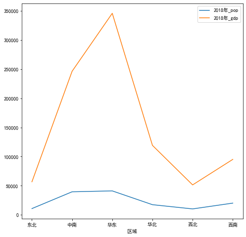

```python
drawdf.plot(ax=ax1)
fig1
```

[figure not shown]

```python
fig2,ax2=plt.subplots(1,2,figsize=(12,6))
```

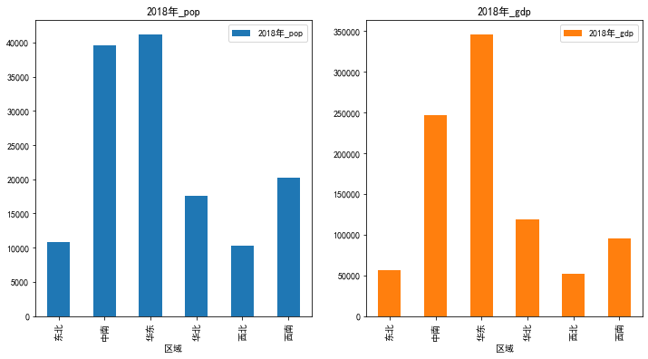

```python
group_region[['2018年_pop','2018年_gdp']].agg(np.sum).plot.bar(ax=ax2,subplots=True)
fig2
```

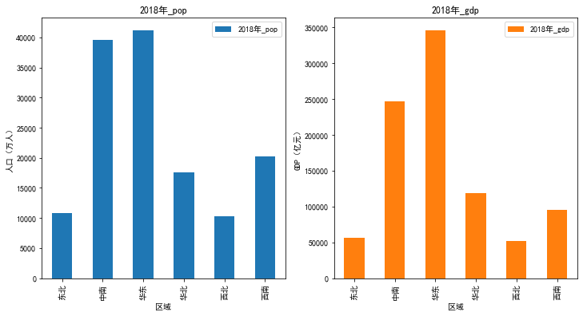

```python
ax2[0].set_ylabel('人口（万人）')
ax2[1].set_ylabel('GDP（亿元）')
fig2
```

```python
fig2.savefig('pop and gdp.jpg',bbox_inches = 'tight')
```

```python
df_sum=group_region[['2018年_pop','2018年_gdp']].agg(np.sum)
df_sum
```

| 区域 | 2018年_pop | 2018年_gdp |
| --- | --- | --- |
| 东北 | 10836 | 56751.59 |
| 中南 | 39627 | 246310.52 |
| 华东 | 41172 | 345737.73 |
| 华北 | 17522 | 119247.22 |
| 西北 | 10279 | 51453.88 |
| 西南 | 20217 | 95206.52 |

```python
df_sum['人均GDP']=df_sum['2018年_gdp']/df_sum['2018年_pop']
df_sum
```

| 区域 | 2018年_pop | 2018年_gdp | 人均GDP |
| --- | --- | --- | --- |
| 东北 | 10836 | 56751.59 | 5.237319 |
| 中南 | 39627 | 246310.52 | 6.215725 |
| 华东 | 41172 | 345737.73 | 8.397399 |
| 华北 | 17522 | 119247.22 | 6.805571 |
| 西北 | 10279 | 51453.88 | 5.005728 |
| 西南 | 20217 | 95206.52 | 4.709231 |

```
array([<AxesSubplot:title={'center':'2018年_pop'}, xlabel='区域'>,
       <AxesSubplot:title={'center':'2018年_gdp'}, xlabel='区域'>,
       <AxesSubplot:title={'center':'人均GDP'}, xlabel='区域'>], dtype=object)
```

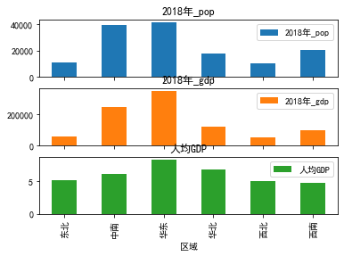

```python
df_sum.plot.bar(subplots=True)
```